# week_08_kmeans_1

## CMPINF 2100 Week 08

### KMeans with 1 variable

## Import Modules

```python
import numpy as np
import pandas as pd
import matplotlib.pyplot as plt

import seaborn as sns
```

## Read data

```python
df = pd.read_csv("cluster1.csv")
```

```python
df.info()
```

```
<class 'pandas.core.frame.DataFrame'>
RangeIndex: 15 entries, 0 to 14
Data columns (total 2 columns):
 #   Column      Non-Null Count  Dtype
---  ------      --------------  -----
 0   true_group  15 non-null     object
 1   x           15 non-null     float64
dtypes: float64(1), object(1)
memory usage: 368.0+ bytes
```

```python
df
```

|  | true_group | x |
| --- | --- | --- |
| 0 | A | -1.546339 |
| 1 | A | -1.775880 |
| 2 | A | -1.249187 |
| 3 | A | -1.677143 |
| 4 | A | -2.747398 |
| 5 | B | 0.756365 |
| 6 | B | 0.679823 |
| 7 | B | 0.045965 |
| 8 | B | 0.543803 |
| 9 | B | -0.687950 |
| 10 | C | 2.581302 |
| 11 | C | 2.257824 |
| 12 | C | 1.938880 |
| 13 | C | 2.899353 |
| 14 | C | 2.066060 |

Lets visualize the obs using a specialized scatter plot. This scatter plot is discussed in detail in CMPINF 2130. The STRIP PLOT.

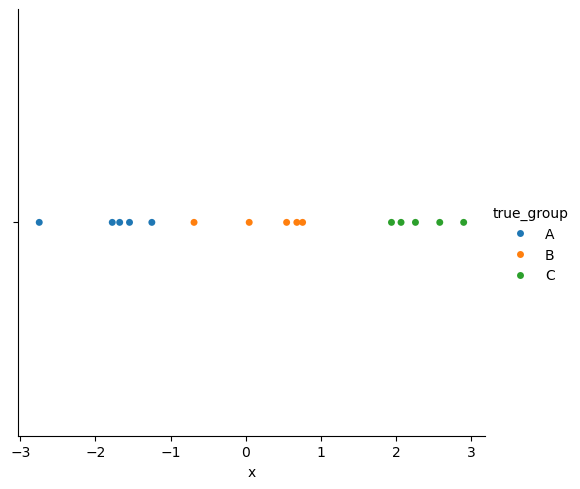

```python
sns.catplot(data=df, x="x", hue="true_group", kind="strip", jitter=False)

plt.show()
```

Lets pretend we do not know the groupings!! Can we CLUSTER the obs just based on their VALUES.

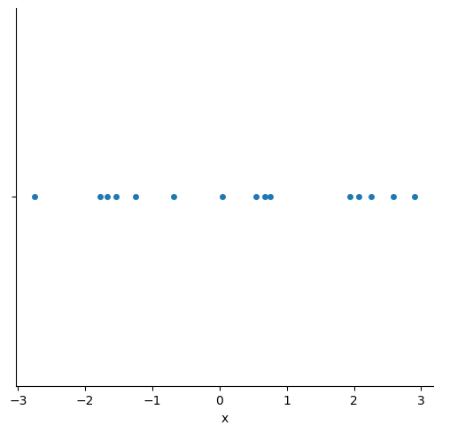

```python
sns.catplot(data=df, x="x", kind="strip", jitter=False)

plt.show()
```

## KMeans

Before we can run KMeans...we need to org the data appropriately! The fx we will use WANTS NumPy arrays and NOT Pandas DataFrames.

The DataFrame NEED to be a 2D array.

```python
df.x.to_numpy()
```

```
array([-1.54633927, -1.77588013, -1.24918706, -1.67714288, -2.74739841,
        0.75636481,  0.67982292,  0.04596469,  0.54380312, -0.68795048,
        2.58130181,  2.25782372,  1.93887976,  2.89935259,  2.06605957])
```

```python
df.x.to_numpy().reshape(-1, 1)
```

```
array([[-1.54633927],
       [-1.77588013],
       [-1.24918706],
       [-1.67714288],
       [-2.74739841],
       [ 0.75636481],
       [ 0.67982292],
       [ 0.04596469],
       [ 0.54380312],
       [-0.68795048],
       [ 2.58130181],
       [ 2.25782372],
       [ 1.93887976],
       [ 2.89935259],
       [ 2.06605957]])
```

```python
X = df.x.to_numpy().reshape(-1, 1)
```

```python
X.ndim
```

```
2
```

```python
X.shape
```

```
(15, 1)
```

```python
X
```

```
array([[-1.54633927],
       [-1.77588013],
       [-1.24918706],
       [-1.67714288],
       [-2.74739841],
       [ 0.75636481],
       [ 0.67982292],
       [ 0.04596469],
       [ 0.54380312],
       [-0.68795048],
       [ 2.58130181],
       [ 2.25782372],
       [ 1.93887976],
       [ 2.89935259],
       [ 2.06605957]])
```

The FUNCTION to executive KMeans comes from scikit-learn MODULE. We rarely import it directly, we import FUNCTIONS from scikit-learn.

The fx is named KMeans() and it comes from the sklearn.cluster module.

```python
from sklearn.cluster import KMeans
```

```python
%whos
```

```
Variable   Type         Data/Info
---------------------------------
KMeans     ABCMeta      <class 'sklearn.cluster._kmeans.KMeans'>
X          ndarray      15x1: 15 elems, type `float64`, 120 bytes
df         DataFrame       true_group         x\n<...>\n14          C  2.066060
np         module       <module 'numpy' from '/Ap<...>kages/numpy/__init__.py'>
pd         module       <module 'pandas' from '/A<...>ages/pandas/__init__.py'>
plt        module       <module 'matplotlib.pyplo<...>es/matplotlib/pyplot.py'>
sns        module       <module 'seaborn' from '/<...>ges/seaborn/__init__.py'>
```

All fxs from scikit-learn follow the following recipe:

- Initialize the object - specify the ASSUMPTIONS for how the method is executed
- FIT the object - LEARN what you need to learn
- PREDICT or TRANSFORM - return the VALUES you want from a FITTED object

Lets begin by INITIALIZING. The ASSUMPTIONS are:

- the num of clusters
- the random seed which controls the randomness - the initial guess
- the num of initial guesses
- the num of iterations for each guess

Lets begin with 3 clusters since we know there are in fact 3 groups in this small application.

```python
km3 = KMeans(n_clusters=3, random_state=121, n_init=25, max_iter=500)
```

```python
type(km3)
```

```
sklearn.cluster._kmeans.KMeans
```

We have not provided any DATA when we INITIALIZE!!!

We give the data when we FIT the object using the assumptions!!

```python
km3 = km3.fit(X)
```

For KMeans FITTING means it identified the CLUSTERS associated with EACH data point!!

TO RETURN the CLUSTER ASSIGNMENTS or CLUSTER LABELS...we need to PREDICT the data!!!

```python
km3.predict(X)
```

```
array([0, 0, 0, 0, 0, 2, 2, 2, 2, 0, 1, 1, 1, 1, 1], dtype=int32)
```

If you only care about the CLUSTER ASSIGNMENTS or CLUSTER LABELS, FITTING and PREDICTING can be combined into a SINGLE action.

```python
km3b = KMeans(n_clusters=3, random_state=121, n_init=25, max_iter=500)
```

```python
km3b.fit_predict(X)
```

```
array([0, 0, 0, 0, 0, 2, 2, 2, 2, 0, 1, 1, 1, 1, 1], dtype=int32)
```

Accompish all three steps into 1 line of CODE!!

```python
KMeans(n_clusters=3, random_state=121, n_init=25, max_iter=500).fit_predict(X)
```

```
array([0, 0, 0, 0, 0, 2, 2, 2, 2, 0, 1, 1, 1, 1, 1], dtype=int32)
```

Lets use the INITIALIZE then FIT and PREDICT approach and study the cluster labels.

To do that, lets create a COPY of the original dataframe.

```python
df
```

|  | true_group | x |
| --- | --- | --- |
| 0 | A | -1.546339 |
| 1 | A | -1.775880 |
| 2 | A | -1.249187 |
| 3 | A | -1.677143 |
| 4 | A | -2.747398 |
| 5 | B | 0.756365 |
| 6 | B | 0.679823 |
| 7 | B | 0.045965 |
| 8 | B | 0.543803 |
| 9 | B | -0.687950 |
| 10 | C | 2.581302 |
| 11 | C | 2.257824 |
| 12 | C | 1.938880 |
| 13 | C | 2.899353 |
| 14 | C | 2.066060 |

```python
df_copy = df.copy()
```

```python
df_copy
```

|  | true_group | x |
| --- | --- | --- |
| 0 | A | -1.546339 |
| 1 | A | -1.775880 |
| 2 | A | -1.249187 |
| 3 | A | -1.677143 |
| 4 | A | -2.747398 |
| 5 | B | 0.756365 |
| 6 | B | 0.679823 |
| 7 | B | 0.045965 |
| 8 | B | 0.543803 |
| 9 | B | -0.687950 |
| 10 | C | 2.581302 |
| 11 | C | 2.257824 |
| 12 | C | 1.938880 |
| 13 | C | 2.899353 |
| 14 | C | 2.066060 |

Create a new col named k3 which stores the RESULTS of the KMeans cluster labels!

```python
df_copy['k3'] = pd.Series(km3.fit_predict(X), index=df_copy.index)
```

```python
df_copy
```

|  | true_group | x | k3 |
| --- | --- | --- | --- |
| 0 | A | -1.546339 | 0 |
| 1 | A | -1.775880 | 0 |
| 2 | A | -1.249187 | 0 |
| 3 | A | -1.677143 | 0 |
| 4 | A | -2.747398 | 0 |
| 5 | B | 0.756365 | 2 |
| 6 | B | 0.679823 | 2 |
| 7 | B | 0.045965 | 2 |
| 8 | B | 0.543803 | 2 |
| 9 | B | -0.687950 | 0 |
| 10 | C | 2.581302 | 1 |
| 11 | C | 2.257824 | 1 |
| 12 | C | 1.938880 | 1 |
| 13 | C | 2.899353 | 1 |
| 14 | C | 2.066060 | 1 |

```python
df_copy.info()
```

```
<class 'pandas.core.frame.DataFrame'>
RangeIndex: 15 entries, 0 to 14
Data columns (total 3 columns):
 #   Column      Non-Null Count  Dtype
---  ------      --------------  -----
 0   true_group  15 non-null     object
 1   x           15 non-null     float64
 2   k3          15 non-null     int32
dtypes: float64(1), int32(1), object(1)
memory usage: 428.0+ bytes
```

```python
df_copy.k3.value_counts()
```

```
k3
0    6
1    5
2    4
Name: count, dtype: int64
```

```python
df_copy.true_group.value_counts()
```

```
true_group
A    5
B    5
C    5
Name: count, dtype: int64
```

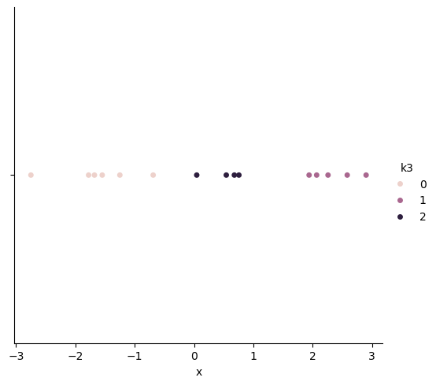

```python
sns.catplot(data=df_copy, x="x", hue="k3", kind="strip", jitter=False)

plt.show()
```

I like to treat cluster labels as CAT variables. Thus, lets CONVERT the integer to the CATEGORY data type!!!

The Pandas Category data type is a specialized data type for CATEGORICAL variables!!!

```python
df_copy["k3"] = df_copy.k3.astype("category")
```

```python
df_copy.info()
```

```
<class 'pandas.core.frame.DataFrame'>
RangeIndex: 15 entries, 0 to 14
Data columns (total 3 columns):
 #   Column      Non-Null Count  Dtype
---  ------      --------------  -----
 0   true_group  15 non-null     object
 1   x           15 non-null     float64
 2   k3          15 non-null     category
dtypes: category(1), float64(1), object(1)
memory usage: 487.0+ bytes
```

```python
df_copy.k3.cat.categories
```

```
Index([0, 1, 2], dtype='int32')
```

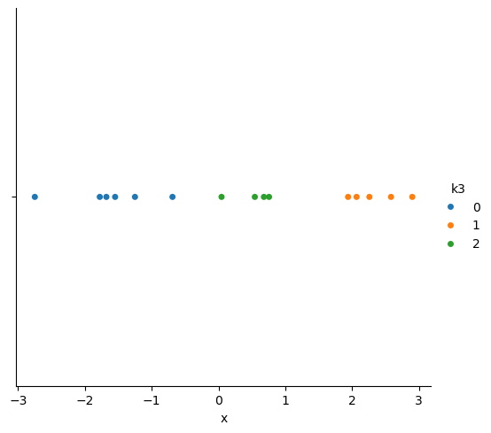

```python
sns.catplot(data=df_copy, x="x", hue="k3", kind="strip", jitter=False)

plt.show()
```

### How do the KMeans results compare to the TRUE answers?

You can NEVER do this in a real data set!

However, you are clustering the ROWS based on NUMERIC cols. This, you are NOT using the cat vars in the clustering! You can therefore compare the CLUSTER results with the known categories!!

Could use DODGED bar chart but I prefer to use a heat map!!

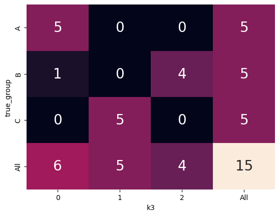

```python
fig, ax = plt.subplots()

sns.heatmap(pd.crosstab(df_copy.true_group, df_copy.k3, margins=True),
            annot=True, annot_kws={"fontsize":20}, cbar=False,
            ax=ax)

plt.show()
```

KMeans has mislabeled or misidentifies 1 of the observations!!

But is KMeans WRONG??? NO!!!!

KMeans groups by DISTANCE!! The closer obs are the more similar KMeans feels they are!!!

Lets visualize what caused the INCORRECT label...

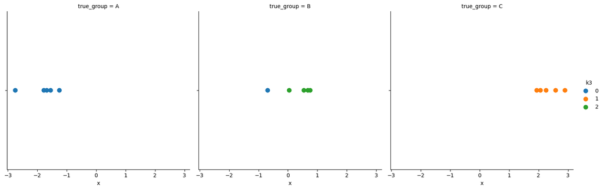

```python
sns.catplot(data=df_copy, x="x", hue="k3", kind="strip", jitter=False, col="true_group", s=75)

plt.show()
```

Lets use the marker SHAPE via the style argument in replot()

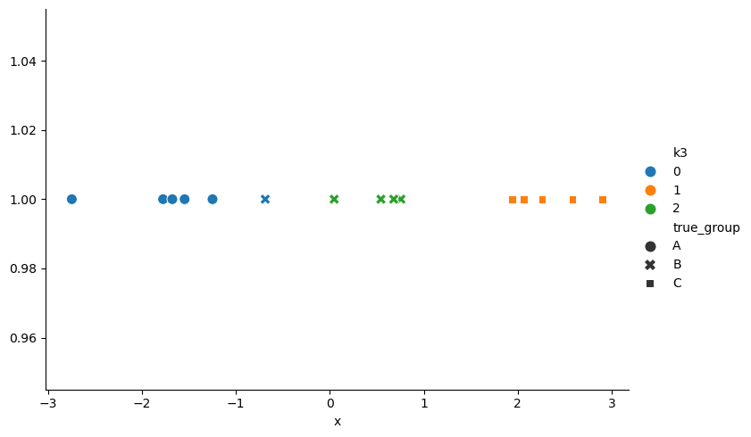

```python
sns.relplot(data=df_copy, x="x", y=1, hue="k3", style="true_group", aspect=1.5, s=75)

plt.show()
```

## More clusters?

Lets try 8 clusters!

```python
km8 = KMeans(n_clusters=8, random_state=121, n_init=25, max_iter=500).fit_predict(X)
```

```python
df_copy['k8'] = pd.Series(km8, index=df_copy.index).astype("category")
```

```python
df_copy
```

|  | true_group | x | k3 | k8 |
| --- | --- | --- | --- | --- |
| 0 | A | -1.546339 | 0 | 0 |
| 1 | A | -1.775880 | 0 | 0 |
| 2 | A | -1.249187 | 0 | 6 |
| 3 | A | -1.677143 | 0 | 0 |
| 4 | A | -2.747398 | 0 | 4 |
| 5 | B | 0.756365 | 2 | 2 |
| 6 | B | 0.679823 | 2 | 2 |
| 7 | B | 0.045965 | 2 | 7 |
| 8 | B | 0.543803 | 2 | 2 |
| 9 | B | -0.687950 | 0 | 3 |
| 10 | C | 2.581302 | 1 | 1 |
| 11 | C | 2.257824 | 1 | 5 |
| 12 | C | 1.938880 | 1 | 5 |
| 13 | C | 2.899353 | 1 | 1 |
| 14 | C | 2.066060 | 1 | 5 |

```python
df_copy.info()
```

```
<class 'pandas.core.frame.DataFrame'>
RangeIndex: 15 entries, 0 to 14
Data columns (total 4 columns):
 #   Column      Non-Null Count  Dtype
---  ------      --------------  -----
 0   true_group  15 non-null     object
 1   x           15 non-null     float64
 2   k3          15 non-null     category
 3   k8          15 non-null     category
dtypes: category(2), float64(1), object(1)
memory usage: 770.0+ bytes
```

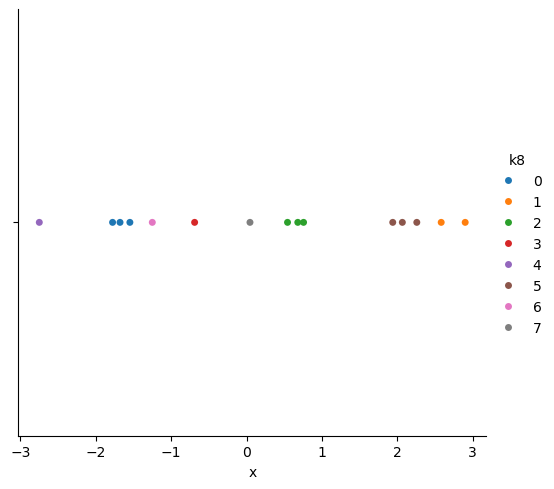

```python
sns.catplot(data=df_copy, x="x", hue="k8", kind="strip", jitter=False)

plt.show()
```

The MAX number of clusters equals the NUMBER OF ROWS in the dataset!

This would give 1 obs PER cluster!!!

```python
k15 = KMeans(n_clusters=15, random_state=121, n_init=25, max_iter=500)
```

```python
df_copy['k15'] = pd.Series(k15.fit_predict(X), index=df_copy.index).astype("category")
```

```python
df_copy
```

|  | true_group | x | k3 | k8 | k15 |
| --- | --- | --- | --- | --- | --- |
| 0 | A | -1.546339 | 0 | 0 | 10 |
| 1 | A | -1.775880 | 0 | 0 | 0 |
| 2 | A | -1.249187 | 0 | 6 | 6 |
| 3 | A | -1.677143 | 0 | 0 | 13 |
| 4 | A | -2.747398 | 0 | 4 | 4 |
| 5 | B | 0.756365 | 2 | 2 | 9 |
| 6 | B | 0.679823 | 2 | 2 | 14 |
| 7 | B | 0.045965 | 2 | 7 | 7 |
| 8 | B | 0.543803 | 2 | 2 | 2 |
| 9 | B | -0.687950 | 0 | 3 | 3 |
| 10 | C | 2.581302 | 1 | 1 | 1 |
| 11 | C | 2.257824 | 1 | 5 | 11 |
| 12 | C | 1.938880 | 1 | 5 | 12 |
| 13 | C | 2.899353 | 1 | 1 | 8 |
| 14 | C | 2.066060 | 1 | 5 | 5 |

```python
df_copy.k15.value_counts()
```

```
k15
0     1
1     1
2     1
3     1
4     1
5     1
6     1
7     1
8     1
9     1
10    1
11    1
12    1
13    1
14    1
Name: count, dtype: int64
```

## Optimal Number of Clusters!!

We want to find the TOTAL WITHIN SUM OF SQUARES that gives INTERESTING behavior!!

We must calc the TOTAL WITHIN SUM OF SQUARES for MANY poss num of clusters!!

The KMeans() objects refer to the TOTAL WITHIN SUM OF SQUARES as the `inertia_` attribute.

We want to minimize the inertia but only to an interesting level!!

```python
tots_within = []

K = range(1, df_copy.shape[0] + 1)

for k in K:
    km = KMeans(n_clusters=k, random_state=121, n_init=25, max_iter=500)
    km = km.fit(X)

    tots_within.append(km.inertia_)
```

```python
tots_within
```

```
[46.35399636931193,
 10.655278557432904,
 3.2293944877041723,
 1.687838009303805,
 1.063014909569858,
 0.5517322559171763,
 0.2824165169327671,
 0.15183268233008237,
 0.10125453161699273,
 0.05778406841556978,
 0.036142712893640266,
 0.015891204992999303,
 0.007803852442986431,
 0.0029293308150693254,
 0.0]
```

Visualize the RESULTS using a LINE CHART.

This is a simple graphic in matplotlib rather than Seaborn. The style of the line chart is the SAME style that we used in the beginning semester when we were plotting the SEM vs the sample size!

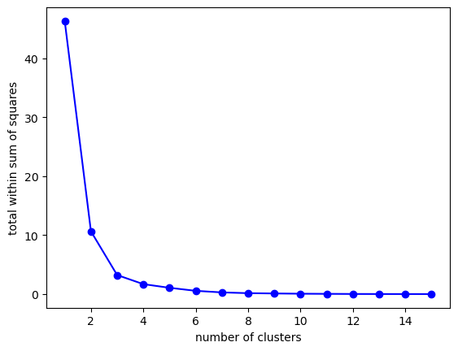

```python
fig, ax = plt.subplots()

ax.plot(K, tots_within, "bo-")
ax.set_xlabel("number of clusters")
ax.set_ylabel("total within sum of squares")

plt.show()
```